# A Reanalysis of Holford (1983)

This is an reanalysis of an example provided in Theodore R. Holford, 1983, [*The Estimation of Age, Period and Cohort Effects for Vital Rates*](https://www.jstor.org/stable/2531004), Biometrics 39(2): 311-324. The data are prostate cancer deaths for nonwhites in the U.S. Age and period are grouped into five-year intervals.

For details on these results, see [this working paper](https://osf.io/preprints/socarxiv/xrbgv/).

## Load packages and data

```r
library("dplyr")
library("ggplot2")
library("texreg")
library("weightedcontrasts")

data("prostate") # provided with weightedcontrasts package
d <- prostate %>%
    mutate(rate = 100000 * deaths / population,
        log_rate = log(rate)) %>%
    mutate(across(c(age, period, cohort), as.factor))
```

## Replication: Figure 2

This is simply a reconstruction of Figure 2 in Holford (1983).

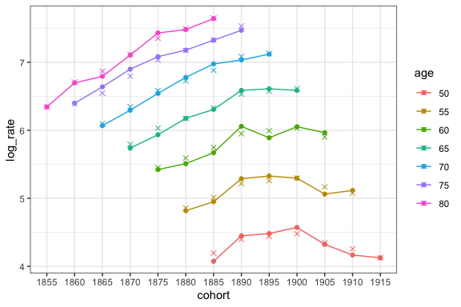

```r
m_ac <- glm(deaths ~ age + cohort + offset(log(d$population)), data = d, family = poisson())
d_pred <- mutate(d, pred = log(predict(m_ac, type = "response") / population * 100000))

p <- d %>%
    ggplot(aes(x = cohort, y = log_rate, color = age, group = age)) +
        geom_point() + geom_line() +
        geom_point(data = d_pred, aes(x = cohort, y = pred), shape = 4, size = 2) +
        theme_bw()
p
```

## Helper functions

The first helper function extracts the non-linear effects from the model, while the second function computes a total (linear and non-linear) effect. The last function is used to override the linear contrast below; this is done to obtain exactly the same point estimates as Holford.

```r
get_deviations <- function(model, set, contrasts) {
    extract_coefs <- coef(model)[grepl(set, names(coef(model)))]
    extract_coefs <- extract_coefs[2:length(extract_coefs)]
    deviations <- contrasts[, 2:(1 + length(extract_coefs)), drop = FALSE] %*% extract_coefs
    deviations[, 1]
}

get_total_effect <- function(contrasts, linear_coef, nonlinear_coefs) {
    linear_contrast <- contrasts[, 1]
    nonlinear_contrasts <- contrasts[, 2:ncol(contrasts)]
    linear_contrast * linear_coef + nonlinear_contrasts %*% nonlinear_coefs
}

get_linear_contrast <- function(vector) {
    1:n_distinct(vector) - 1/2 * n_distinct(vector) - 1/2
}
```

## Holford’s original model

We first replicate Holford’s original model. The built-in R function `contr.poly` uses unweighted orthogonal polynomials. We then use one of the helper functions defined above to extract the identified non-linear effects.

```r
data_holford <- as_tibble(d)

# use contr.poly but adjust for the linear term
contrasts(data_holford$age) <- contr.poly
contrasts(data_holford$age)[, 1] <- get_linear_contrast(data_holford$age)
contrasts(data_holford$period) <- contr.poly
contrasts(data_holford$period)[, 1] <- get_linear_contrast(data_holford$period)
contrasts(data_holford$cohort) <- contr.poly
contrasts(data_holford$cohort)[, 1] <- get_linear_contrast(data_holford$cohort)

holford <- glm(deaths ~ age + cohort + period + offset(log(data_holford$population)),
    data = data_holford, family = poisson())

# get deviations from linear trend and age/cohort linear effects
# (these are the true linear effects when period linear effect = 0)
holford_age <- get_deviations(holford, "^age", contrasts(data_holford$age))
holford_period <- get_deviations(holford, "^period", contrasts(data_holford$period))
holford_cohort <- get_deviations(holford, "^cohort", contrasts(data_holford$cohort))
holford_age_linear <- coef(holford)["age.L"]
holford_cohort_linear <- coef(holford)["cohort.L"]
```

## Corrected model

This code is very similar, but uses the function `contr.poly.weighted` from the [`weightedcontrasts`](https://github.com/elbersb/weightedcontrasts) package. We also specify the width of the age groups (5-year intervals in this case), to obtain an interpretable linear term.

```r
data_corrected <- as_tibble(d)

contrasts(data_corrected$age) <- contr.poly.weighted(data_corrected$age, width = 5)
contrasts(data_corrected$period) <- contr.poly.weighted(data_corrected$period, width = 5)
contrasts(data_corrected$cohort) <- contr.poly.weighted(data_corrected$cohort, width = 5)
# zero out the period linear effect
contrasts(data_corrected$period)[, 1] <- 0

corrected <- glm(deaths ~ age + cohort + period + offset(log(data_corrected$population)),
    data = data_corrected, family = poisson())

# get deviations from linear trend and age/cohort linear effects
# (these are the true linear effects when period linear effect = 0)
corrected_age <- get_deviations(corrected, "^age", contrasts(data_corrected$age))
corrected_period <- get_deviations(corrected, "^period", contrasts(data_corrected$period))
corrected_cohort <- get_deviations(corrected, "^cohort", contrasts(data_corrected$cohort))
corrected_age_linear <- coef(corrected)["age.L"]
corrected_cohort_linear <- coef(corrected)["cohort.L"]
```

## More parsimonious model

```r
designmatrix <- model.matrix(deaths ~ age + cohort + period + offset(log(data_corrected$population)),
    data = data_corrected)
d_reduced <- designmatrix[, c("age.L", "cohort.L", "period.L", "age.Q", "cohort.Q", "period.Q")] %>%
    as_tibble() %>%
    mutate(deaths = d$deaths, population = d$population)
corrected_p <- glm(deaths ~ age.L + cohort.L + period.L + age.Q + cohort.Q + period.Q +
    offset(log(population)), data = d_reduced, family = poisson())
```

## Comparison

```r
htmlreg(list(holford, corrected, corrected_p), single.row = TRUE)
```

Statistical models

|  | Model 1 | Model 2 | Model 3 |
| --- | --- | --- | --- |
| (Intercept) | -5.59 (0.01)*** | -5.47 (0.01)*** | -5.48 (0.01)*** |
| age.L | 0.58 (0.00)*** | 0.12 (0.00)*** | 0.12 (0.00)*** |
| age.Q | -0.44 (0.02)*** | -0.44 (0.02)*** | -0.47 (0.02)*** |
| age.C | 0.00 (0.02) | 0.00 (0.02) |  |
| age^4 | -0.02 (0.01) | -0.02 (0.01) |  |
| age^5 | -0.02 (0.01) | -0.02 (0.01) |  |
| age^6 | 0.02 (0.01) | 0.02 (0.01) |  |
| cohort.L | 0.12 (0.00)*** | 0.02 (0.00)*** | 0.03 (0.00)*** |
| cohort.Q | -0.84 (0.06)*** | -0.91 (0.05)*** | -0.99 (0.04)*** |
| cohort.C | -0.17 (0.06)** | -0.26 (0.05)*** |  |
| cohort^4 | -0.02 (0.05) | -0.03 (0.05) |  |
| cohort^5 | 0.11 (0.04)* | 0.12 (0.04)** |  |
| cohort^6 | -0.01 (0.04) | 0.02 (0.04) |  |
| cohort^7 | 0.02 (0.03) | 0.01 (0.03) |  |
| cohort^8 | -0.07 (0.03)* | -0.07 (0.03)** |  |
| cohort^9 | 0.02 (0.02) | 0.03 (0.02) |  |
| cohort^10 | -0.01 (0.02) | -0.01 (0.02) |  |
| cohort^11 | -0.04 (0.02)** | -0.04 (0.02)** |  |
| cohort^12 | -0.02 (0.01) | -0.02 (0.01) |  |
| period.Q | -0.07 (0.02)*** | -0.07 (0.02)*** | -0.05 (0.02)** |
| period.C | -0.01 (0.02) | -0.01 (0.02) |  |
| period^4 | 0.04 (0.02)** | 0.04 (0.02)** |  |
| period^5 | 0.01 (0.01) | 0.01 (0.01) |  |
| period^6 | -0.01 (0.01) | -0.01 (0.01) |  |
| AIC | 553.18 | 553.18 | 635.56 |
| BIC | 598.59 | 598.59 | 646.91 |
| Log Likelihood | -252.59 | -252.59 | -311.78 |
| Deviance | 98.91 | 98.91 | 217.29 |
| Num. obs. | 49 | 49 | 49 |

p < 0.001; p < 0.01; p < 0.05

```r
# does not affect age and period terms
all.equal(holford_age, corrected_age)
```

```
#> [1] TRUE
```

```r
all.equal(holford_period, corrected_period)
```

```
#> [1] TRUE
```

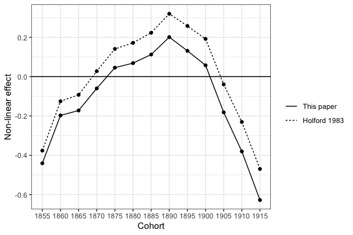

```r
# comparison of cohort non-linear effects
p <- tibble(effect = c(corrected_cohort, holford_cohort),
    cohort = rep(names(corrected_cohort), 2),
    which = c(rep("This paper", length(corrected_cohort)),
        rep("Holford 1983", length(holford_cohort)))) %>%
    mutate(which = factor(which, levels = c("This paper", "Holford 1983"))) %>%
    ggplot(aes(x = cohort, y = effect, group = which, linetype = which)) +
    geom_point() + geom_line() +
    geom_hline(yintercept = 0) +
    labs(y = "Non-linear effect", x = "Cohort", group = "", linetype = "") +
    theme_bw()
p
```